# Analyse de données - Brain Stroke

Idir SADAOUI, Hamady CISSÉ

Un Brain Stroke (ou accident vasculaire cérébral en français) est l’arrêt brutal de la circulation sanguine au niveau d’une partie du cerveau).  
Il y a deux types d'AVC :

- Les AVC ischémiques qui sont dus à un caillot dans une artère.
- Les AVC hémorragiques qui sont dus à une hémorragie, par lésions des parois du vaisseau.

## Importation des libraries nécéssaires

```python
import numpy as np
import matplotlib.pyplot as plt
plt.rcParams['figure.figsize'] = [10, 5]
import seaborn as sns
import pandas as pd
from sklearn.preprocessing import MinMaxScaler
from imblearn.over_sampling import RandomOverSampler
from sklearn.model_selection import train_test_split
from sklearn.neighbors import KNeighborsClassifier
from sklearn.ensemble import RandomForestClassifier
from sklearn.neural_network import MLPClassifier
from sklearn.linear_model import LogisticRegression
from sklearn import svm
from sklearn.metrics import recall_score, accuracy_score, f1_score, confusion_matrix, precision_score
from sklearn.model_selection import ShuffleSplit, cross_val_score
```

## Analyse descriptive du jeu de données

```python
data = pd.read_csv("brain_stroke.csv", sep=",")
```

```python
data.head()
```

|  | gender | age | hypertension | heart_disease | ever_married | work_type | Residence_type | avg_glucose_level | bmi | smoking_status | stroke |
| --- | --- | --- | --- | --- | --- | --- | --- | --- | --- | --- | --- |
| 0 | Male | 67.0 | 0 | 1 | Yes | Private | Urban | 228.69 | 36.6 | formerly smoked | 1 |
| 1 | Male | 80.0 | 0 | 1 | Yes | Private | Rural | 105.92 | 32.5 | never smoked | 1 |
| 2 | Female | 49.0 | 0 | 0 | Yes | Private | Urban | 171.23 | 34.4 | smokes | 1 |
| 3 | Female | 79.0 | 1 | 0 | Yes | Self-employed | Rural | 174.12 | 24.0 | never smoked | 1 |
| 4 | Male | 81.0 | 0 | 0 | Yes | Private | Urban | 186.21 | 29.0 | formerly smoked | 1 |

Voici un premier aperçu du jeu de données.

```python
data.shape
```

```
(4981, 11)
```

```python
data.info()
```

```
<class 'pandas.core.frame.DataFrame'>
RangeIndex: 4981 entries, 0 to 4980
Data columns (total 11 columns):
 #   Column             Non-Null Count  Dtype
---  ------             --------------  -----
 0   gender             4981 non-null   object
 1   age                4981 non-null   float64
 2   hypertension       4981 non-null   int64
 3   heart_disease      4981 non-null   int64
 4   ever_married       4981 non-null   object
 5   work_type          4981 non-null   object
 6   Residence_type     4981 non-null   object
 7   avg_glucose_level  4981 non-null   float64
 8   bmi                4981 non-null   float64
 9   smoking_status     4981 non-null   object
 10  stroke             4981 non-null   int64
dtypes: float64(3), int64(3), object(5)
memory usage: 428.2+ KB
```

Toutes les variables sont du bons types, il n'y a donc pas de modification à faire à ce niveau là.  
Nous allons maintenant vérifier si le jeu de données présente des valeurs manquantes :

```python
data.isna().sum()
```

```
gender               0
age                  0
hypertension         0
heart_disease        0
ever_married         0
work_type            0
Residence_type       0
avg_glucose_level    0
bmi                  0
smoking_status       0
stroke               0
dtype: int64
```

Aucune valeurs manquantes à signaler.  
On peut aussi regarder les statistiques de base des variables quantitatives :

```python
data.select_dtypes(include='float64').describe()
```

|  | age | avg_glucose_level | bmi |
| --- | --- | --- | --- |
| count | 4981.000000 | 4981.000000 | 4981.000000 |
| mean | 43.419859 | 105.943562 | 28.498173 |
| std | 22.662755 | 45.075373 | 6.790464 |
| min | 0.080000 | 55.120000 | 14.000000 |
| 25% | 25.000000 | 77.230000 | 23.700000 |
| 50% | 45.000000 | 91.850000 | 28.100000 |
| 75% | 61.000000 | 113.860000 | 32.600000 |
| max | 82.000000 | 271.740000 | 48.900000 |

et la distribution des variables qualitatives:

```python
donnees_categorielles = data.select_dtypes(include='object')

for i in donnees_categorielles.columns:
    print(donnees_categorielles[i].value_counts())
    print()
```

```
Female    2907
Male      2074
Name: gender, dtype: int64

Yes    3280
No     1701
Name: ever_married, dtype: int64

Private          2860
Self-employed     804
children          673
Govt_job          644
Name: work_type, dtype: int64

Urban    2532
Rural    2449
Name: Residence_type, dtype: int64

never smoked       1838
Unknown            1500
formerly smoked     867
smokes              776
Name: smoking_status, dtype: int64
```

Enfin on trace une matrice de corrélation pour avoir un premier aperçu de potentiels corrélations entre des variables :

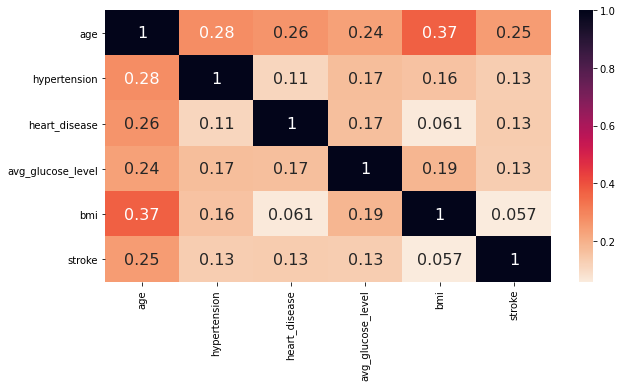

```python
sns.heatmap(data.corr(), annot=True, cmap="rocket_r" ,annot_kws={"size": 16})
```

À première vue, l'indice de masse corporelle et l'âge sont les variables les plus corrélées entre elles bien que cela soit assez faible.  
Nous allons maintenant associer à `y` la colonne **stroke** qui est la target et à `X` les variables caractéristiques.

```python
y = data.stroke
X = data.drop("stroke",axis=1)
```

Nous pouvons maintenant attaquer l'étape de la préparation des données.

## Preprocessing

Grâce à la visualisation rapide du jeu de données effectué en début d'analyse, nous avons vu que 5 des 10 variables explicatives sont qualitatives de type `objet`.  
Nous avons décider de recoder ces variables grâce à la fonction `get_dummies` de `pandas` qui va créer de nouvelles colonnes binaires en faisant pivoter les colonnes des variables qualitatives :

```python
X = pd.get_dummies(data = X,columns = donnees_categorielles.columns)
X.head()
```

|  | age | hypertension | heart_disease | avg_glucose_level | bmi | gender_Female | gender_Male | ever_married_No | ever_married_Yes | work_type_Govt_job | work_type_Private | work_type_Self-employed | work_type_children | Residence_type_Rural | Residence_type_Urban | smoking_status_Unknown | smoking_status_formerly smoked | smoking_status_never smoked | smoking_status_smokes |
| --- | --- | --- | --- | --- | --- | --- | --- | --- | --- | --- | --- | --- | --- | --- | --- | --- | --- | --- | --- |
| 0 | 67.0 | 0 | 1 | 228.69 | 36.6 | 0 | 1 | 0 | 1 | 0 | 1 | 0 | 0 | 0 | 1 | 0 | 1 | 0 | 0 |
| 1 | 80.0 | 0 | 1 | 105.92 | 32.5 | 0 | 1 | 0 | 1 | 0 | 1 | 0 | 0 | 1 | 0 | 0 | 0 | 1 | 0 |
| 2 | 49.0 | 0 | 0 | 171.23 | 34.4 | 1 | 0 | 0 | 1 | 0 | 1 | 0 | 0 | 0 | 1 | 0 | 0 | 0 | 1 |
| 3 | 79.0 | 1 | 0 | 174.12 | 24.0 | 1 | 0 | 0 | 1 | 0 | 0 | 1 | 0 | 1 | 0 | 0 | 0 | 1 | 0 |
| 4 | 81.0 | 0 | 0 | 186.21 | 29.0 | 0 | 1 | 0 | 1 | 0 | 1 | 0 | 0 | 0 | 1 | 0 | 1 | 0 | 0 |

Nous voyons que chaques classes de chaques variables explicatives possède maintenant sa propre colonne composée de 1 et de 0.  
Nous remarquons que les variables quantitatives ne sont pas du même ordre de grandeur que les autres, elles sont beaucoup trop grandes, il est important de les normaliser.  
Pour cela nous avons choisi la normalisation MinMax grâce à la fonction `MinMaxScaler` de `scikit-learn`.  
La formule utilisé par cette normalisation est la suivante :

$$ \frac{X_{i} - X_{min}}{X_{max}-X_{min}} $$

avec $X_{i}$ l'observation $i$ pour $i$ = {1,...,4981}, $X_{max}$ et $X_{min}$ respectivement les valeurs maximal et minimal de la colonne.

```python
donnees_numeriques = data.select_dtypes(include='float64')
scaler = MinMaxScaler()
for i in donnees_numeriques:
    X[i] = scaler.fit_transform(X[[i]])
```

Voila le résultat final sur les 5 premiers patients :

```python
X.head()
```

|  | age | hypertension | heart_disease | avg_glucose_level | bmi | gender_Female | gender_Male | ever_married_No | ever_married_Yes | work_type_Govt_job | work_type_Private | work_type_Self-employed | work_type_children | Residence_type_Rural | Residence_type_Urban | smoking_status_Unknown | smoking_status_formerly smoked | smoking_status_never smoked | smoking_status_smokes |
| --- | --- | --- | --- | --- | --- | --- | --- | --- | --- | --- | --- | --- | --- | --- | --- | --- | --- | --- | --- |
| 0 | 0.816895 | 0 | 1 | 0.801265 | 0.647564 | 0 | 1 | 0 | 1 | 0 | 1 | 0 | 0 | 0 | 1 | 0 | 1 | 0 | 0 |
| 1 | 0.975586 | 0 | 1 | 0.234512 | 0.530086 | 0 | 1 | 0 | 1 | 0 | 1 | 0 | 0 | 1 | 0 | 0 | 0 | 1 | 0 |
| 2 | 0.597168 | 0 | 0 | 0.536008 | 0.584527 | 1 | 0 | 0 | 1 | 0 | 1 | 0 | 0 | 0 | 1 | 0 | 0 | 0 | 1 |
| 3 | 0.963379 | 1 | 0 | 0.549349 | 0.286533 | 1 | 0 | 0 | 1 | 0 | 0 | 1 | 0 | 1 | 0 | 0 | 0 | 1 | 0 |
| 4 | 0.987793 | 0 | 0 | 0.605161 | 0.429799 | 0 | 1 | 0 | 1 | 0 | 1 | 0 | 0 | 0 | 1 | 0 | 1 | 0 | 0 |

On va maintenant s'interesser à la variable target `y` en comptant le nombre d'occurences des deux classes:

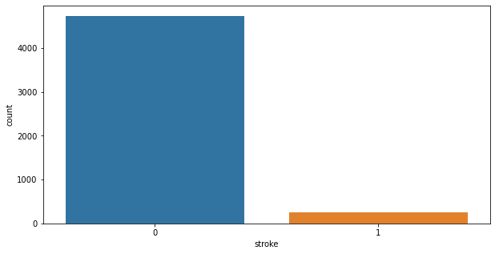

```python
sns.countplot(y)
```

On s'apperçoit que les deux classes sont totalement déséquilibrées, cela peut avoir une incidence sur la performance des modèles d'apprentissage.  
Une solution est de sur-échantilloner la classe minoritaire en tirant des échantillons au hasard, c'est ce que fait la fonction `RandomOverSampler` de `imblearn` :

```python
oversample = RandomOverSampler(sampling_strategy='minority')

X, y = oversample.fit_resample(X, y)
```

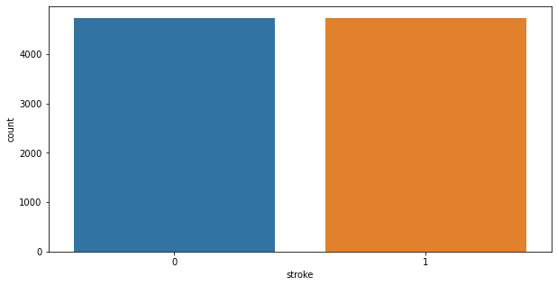

```python
sns.countplot(y)
```

Nous avons maintenant un équilibre parfait entre les classes, nous pouvons commencer à entrainer nos données pour l'apprentissage.

## Entrainements et évaluations

Dans cette analyse, nous avons selectionner 5 algorithmes de machine learning :

- La régression logistique
- Les Support Vector Machine
- Les k-plus proches voisins
- Le perceptron multi-couches
- Les forêts aléatoires

On va d'abord couper notre jeux de données en deux grâce à la fonction `train_test_split` de `scikit-learn` en créant un jeu de données d'entrainement et un jeu de données de test, avec un jeu de test de taille égale à 20% du jeu de données d'origine :

```python
X_train, X_test, y_train, y_test = train_test_split(X, y, test_size=0.2, random_state=25)
```

puis on entraine notre jeu de données d'entrainement avec tout les algorithmes :  
Nous avons essayer de trouver les meilleurs hyperparamètres pour chaque modèles grâce à la fonction `GridSearchCV` de `scikit-learn` mais les hyperparamètres les plus optimaux pour chaque modèle étaient ceux par défaut.  
En ce qui concerne les Perceptrons multi-couches, nous avons construit un réseau de neurones de 4 couches cachées composés de 100 neurones chacunes et un nombre d'itérations maximum de 1000 (qui n'est pas atteint car la condition que nous avons fixé à été satisfaite à savoir ici d'arrêter l'algorithme si le loss ne change pas de l'ordre de 10$^{-4}$ après 20 itérations consécutives).

```python
modeles = {"Régression logistique": LogisticRegression(),
           "Support Vector Machine": svm.SVC(),
           "k-plus proches voisins": KNeighborsClassifier(),
           "Perceptrons multi-couches": MLPClassifier(hidden_layer_sizes=(100,100,100,100),random_state = 1 , verbose = False,
                      n_iter_no_change=20, tol = 0.0001,max_iter=1000),
           "Forêts aléatoires": RandomForestClassifier()}

for algo_nom, algo in modeles.items():
    algo=algo.fit(X_train,y_train)
    print(algo_nom + " entrainé ✔")
```

```
Régression logistique entrainé ✔
Support Vector Machine entrainé ✔
k-plus proches voisins entrainé ✔
Perceptrons multi-couches entrainé ✔
Forêts aléatoires entrainé ✔
```

Nos modèles ont bien été entrainé.  
Nous pouvons visualiser les performances sur la prédiction des données de test grâce à la fonction `confusion_matrix` de `scikit-learn` et en construisant une matrice de heatmap :

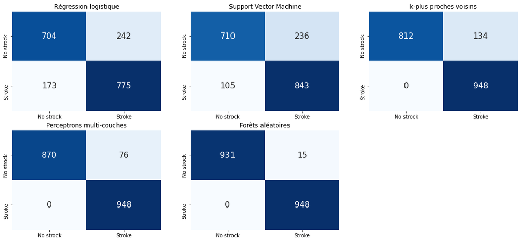

```python
fig, axes = plt.subplots(2, 3, figsize=(18, 8))

i = [0,0,0,1,1]
j = [0,1,2,0,1]
z = 0

for algo_nom, algo in modeles.items():
    matrix_conf = confusion_matrix(y_test,algo.predict(X_test))
    sns.heatmap(matrix_conf, annot=True, cmap='Blues',annot_kws={"size": 16},fmt='d', cbar=False,
           xticklabels=['No strock','Stroke'],yticklabels=['No strock','Stroke'],ax=axes[i[z],j[z]]).set_title(algo_nom)
    z += 1

fig.delaxes(axes[1,2])
```

À première vue, les Forêts aléatoires semblent être ceux qui classent le mieux les données du jeu de test.  
À l'inverse, la Régression logistique semble être celui qui les classent le moins bien.  
Nous allons à présent calculer les différents scores de performances de chaque modèles : l'Accuracy, le Recall, la Precison ainsi que le F1-Score.  
Ces métriques sont données par les formules suivantes :

$$Accuracy = \frac{Nombre \ de \ prédictions \ correctes}{Nombre \ de \ prédictions \ total} \ ; \ Recall = \frac{Vrai \ Positif}{Vrai \ Positif \ + \ Faux \ Négatif} $$

$$ Precision = \frac{Vrai \ Positif}{Vrai \ Positif \ + \ Faux \ Positif} \ ; \ F1\_Score = 2 \ * \ \frac{Recall \ * \ Precision}{Recall \ + \ Precision} $$

```python
tableau = []
for algo_nom, algo in modeles.items():
    y_pred = algo.predict(X_test)
    acc = algo_nom,algo.score(X_test, y_test),recall_score(y_test, y_pred),precision_score(y_test, y_pred),f1_score(y_test, y_pred)
    tableau.append(acc)
    tableauFINAL = pd.DataFrame(tableau, columns=['Modèle','Accuracy','Recall','Precision','F1_Score'])

tableauFINAL.sort_values('Accuracy', ascending = False)
```

|  | Modèle | Accuracy | Recall | Precision | F1_Score |
| --- | --- | --- | --- | --- | --- |
| 4 | Forêts aléatoires | 0.992080 | 1.000000 | 0.984424 | 0.992151 |
| 3 | Perceptrons multi-couches | 0.959873 | 1.000000 | 0.925781 | 0.961460 |
| 2 | k-plus proches voisins | 0.929250 | 1.000000 | 0.876155 | 0.933990 |
| 1 | Support Vector Machine | 0.819958 | 0.889241 | 0.781279 | 0.831771 |
| 0 | Régression logistique | 0.780887 | 0.817511 | 0.762045 | 0.788804 |

```python
CVScores = []
for algo_nom, algo in modeles.items():
    cv = ShuffleSplit(5, test_size = 0.2)
    add = cross_val_score(algo,X_train, y_train, cv=cv).mean()
    CVScores.append(add)
    print("{} {}%".format(algo_nom,round(add*100,3)))
```

```
Régression logistique 77.835%
Support Vector Machine 81.875%
k-plus proches voisins 91.591%
Perceptrons multi-couches 95.142%
Forêts aléatoires 98.759%
```

On voit bien que la moyenne pour chaque modèle est en accord avec les performances de ces derniers.

## Conclusion

Les forêts aléatoires sont les plus adaptées pour ces données avec comme critère l'indice de Gini et avec 100 arbres.